# Pertemuan 1

## Library/Packages

```r
library("forecast")
```

```r
library("graphics")
library("TTR")
library("TSA")
library("readxl")
library("ggplot2")
```

## Impor Data

```r
data <- read_excel("C:\\Users\\ASUS\\OneDrive\\Dokumen\\100 Data Kelompok.xlsx")
head(data)
```

```
## # A tibble: 6 × 2
##   date       rail_monorail
##   <chr>              <dbl>
## 1 2024-08-31         61590
## 2 2024-09-01         39374
## 3 2024-09-02         48918
## 4 2024-09-03         49734
## 5 2024-09-04         55323
## 6 2024-09-05         55233
```

## Eksplorasi Data

```r
View(data)
str(data)
```

```
## tibble [100 × 2] (S3: tbl_df/tbl/data.frame)
##  $ date         : chr [1:100] "2024-08-31" "2024-09-01" "2024-09-02" "2024-09-03" ...
##  $ rail_monorail: num [1:100] 61590 39374 48918 49734 55323 ...
```

```r
dim(data)
```

```
## [1] 100   2
```

Mengubah data agar terbaca sebagai data deret waktu dengan fungsi `ts()` .

```r
data.ts <- ts(data$'rail_monorail')
data.ts
```

```
## Time Series:
## Start = 1
## End = 100
## Frequency = 1
##   [1] 61590 39374 48918 49734 55323 55233 58146 54283 48146 55820 56036 55484
##  [13] 53859 56406 53480 60805 56322 43844 57129 57825 57619 45546 40791 52811
##  [25] 52510 52448 54153 57523 49231 46263 53943 55766 55536 57965 63921 54962
##  [37] 54620 58107 57264 55632 56378 60192 51401 50432 56347 55824 57187 57334
##  [49] 59984 48903 46719 56305 56816 56379 57070 60275 53691 46984 55910 57846
##  [61] 60904 58974 60450 52147 45468 57726 56393 58384 59136 62249 56049 49581
##  [73] 59504 58746 57753 58757 60945 50028 47832 57658 59075 58457 60464 64312
##  [85] 55863 48432 59507 59580 58705 61035 64625 60964 56509 57998 57483 58217
##  [97] 58664 65202 60526 55712
```

Menampilkan ringkasan data

```r
summary(data.ts)
```

```
##    Min. 1st Qu.  Median    Mean 3rd Qu.    Max.
##   39374   53817   56400   55664   58715   65202
```

Membuat plot data deret waktu

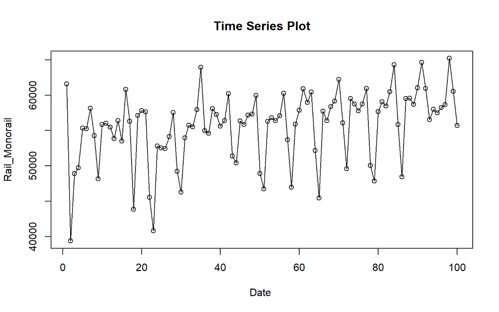

```r
ts.plot(data.ts, xlab="Date ", ylab="Rail_Monorail",
        main = "Time Series Plot")
points(data.ts)
```

## Pembagian Data

```r
colnames(data)[2] <- "rail_monorail"

# hitung jumlah data
n <- nrow(data)

# tentukan batas 80%
n_train <- floor(0.8 * n)

# bagi data
training_ma <- data[1:n_train, ]
testing_ma  <- data[(n_train+1):n, ]

# ubah ke time series
training_ma$date <- as.Date(training_ma$date)
testing_ma$date <- as.Date(testing_ma$date)

train_ma.ts <- ts(training_ma$rail_monorail)
test_ma.ts  <- ts(testing_ma$rail_monorail)
```

Eksplorasi data dilakukan pada keseluruhan data, data latih serta data uji menggunakan plot data deret waktu.

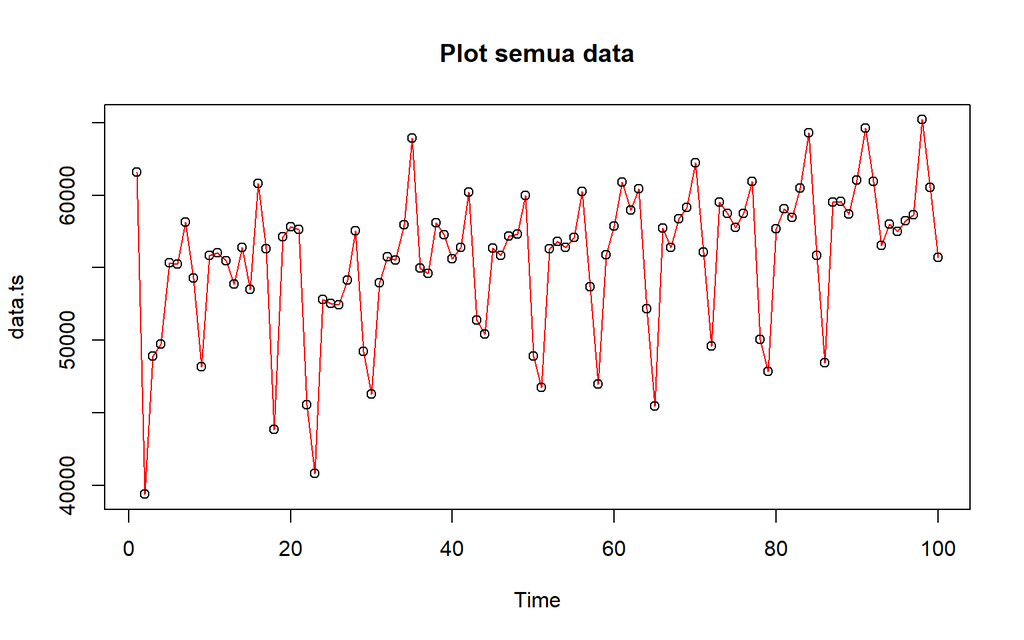

```r
#eksplorasi keseluruhan data
plot(data.ts, col="red",main="Plot semua data")
points(data.ts)
```

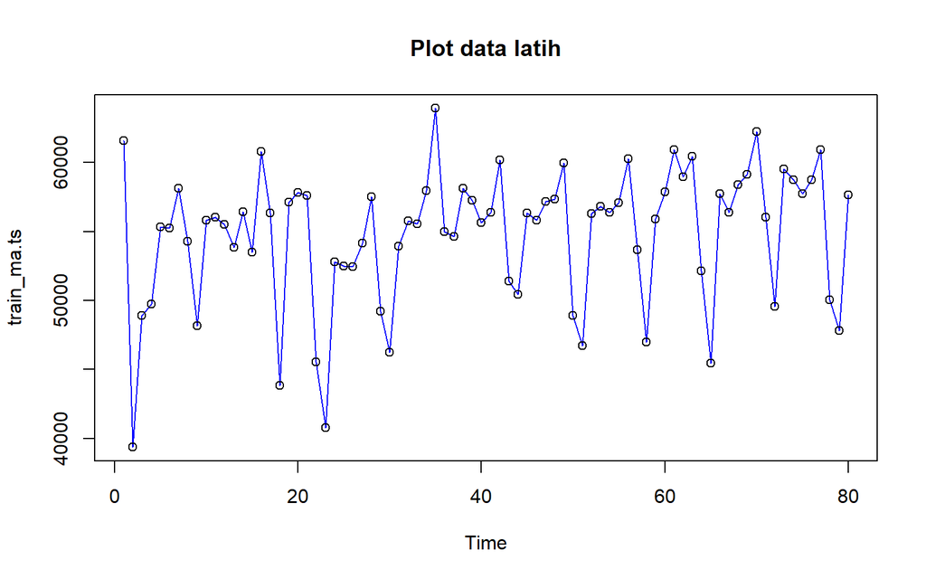

```r
#eksplorasi data latih
plot(train_ma.ts, col="blue",main="Plot data latih")
points(train_ma.ts)
```

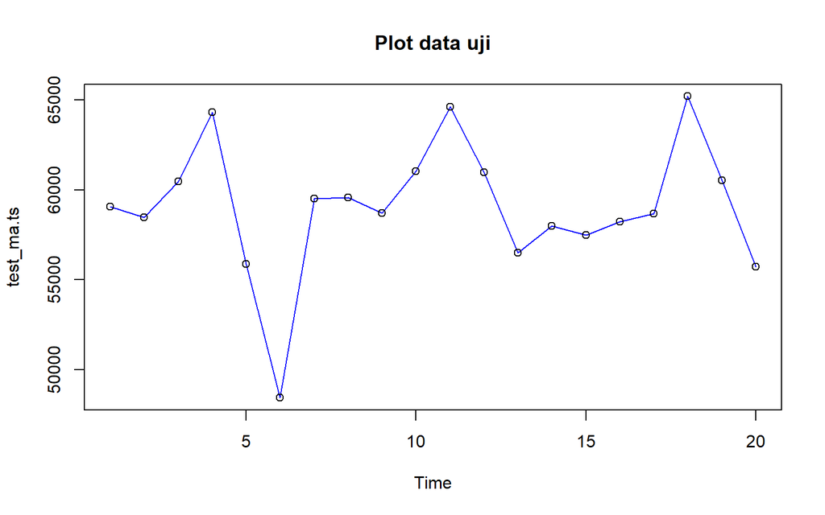

```r
#eksplorasi data uji
plot(test_ma.ts, col="blue",main="Plot data uji")
points(test_ma.ts)
```

Eksplorasi data menggunakan package `ggplot2`.

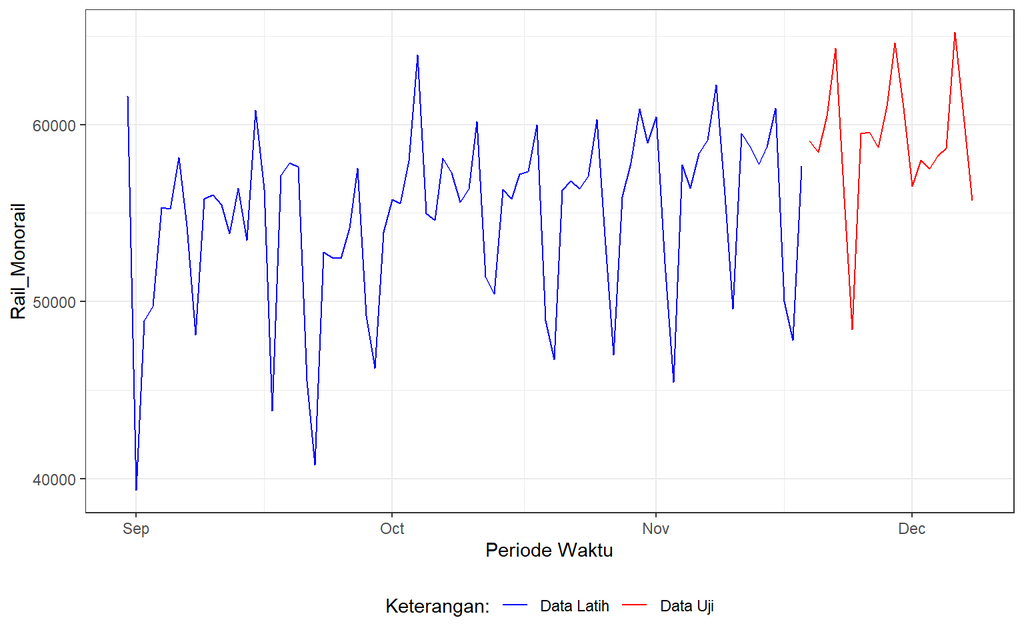

```r
ggplot() +
  geom_line(data = training_ma, aes(x = date, y = rail_monorail, col = "Data Latih")) +
  geom_line(data = testing_ma, aes(x = date, y = rail_monorail, col = "Data Uji")) +
  labs(x = "Periode Waktu", y = "Rail_Monorail", color = "Legend") +
   scale_colour_manual(name="Keterangan:", breaks = c("Data Latih", "Data Uji"),
                      values = c("blue", "red")) +
  theme_bw() + theme(legend.position = "bottom",
                     plot.caption = element_text(hjust=0.5, size=12))
```

# Single Moving Average (SMA)

Ide dasar dari Single Moving Average (SMA) adalah data suatu periode dipengaruhi oleh data periode sebelumnya. Metode pemulusan ini cocok digunakan untuk pola data stasioner atau konstan. Prinsip dasar metode pemulusan ini adalah data pemulusan pada periode ke-t merupakan rata rata dari m buah data pada periode ke-t hingga periode ke (t-m+1).

$$S_t = \frac{1}{m} \sum_{i=t-m+1}^{t} X_i$$

Data pemulusan pada periode ke-t selanjutnya digunakan sebagai nilai peramalan pada periode ke t+1.

$$F_t = S_{t-1}, F_{n,h} = S_n$$

## Pemulusan

Pemulusan menggunakan metode SMA dilakukan dengan fungsi `SMA()`. Dalam hal ini akan dilakukan pemulusan dengan parameter `m=4`.

```r
data.sma<-SMA(train_ma.ts, n=4)
data.sma
```

```
## Time Series:
## Start = 1
## End = 80
## Frequency = 1
##  [1]       NA       NA       NA 49904.00 48337.25 52302.00 54609.00 55746.25
##  [9] 53952.00 54098.75 53571.25 53871.50 55299.75 55446.25 54807.25 56137.50
## [17] 56753.25 53612.75 54525.00 53780.00 54104.25 54529.75 50445.25 49191.75
## [25] 47914.50 49640.00 52980.50 54158.50 53338.75 51792.50 51740.00 51300.75
## [33] 52877.00 55802.50 58297.00 58096.00 57867.00 57902.50 56238.25 56405.75
## [41] 56845.25 57366.50 55900.75 54600.75 54593.00 53501.00 54947.50 56673.00
## [49] 57582.25 55852.00 53235.00 52977.75 52185.75 54054.75 56642.50 57635.00
## [57] 56853.75 54505.00 54215.00 53607.75 55411.00 58408.50 59543.50 58118.75
## [65] 54259.75 53947.75 52933.50 54492.75 57909.75 59040.50 58954.50 56753.75
## [73] 56845.75 55970.00 56396.00 58690.00 59050.25 56870.75 54390.50 54115.75
```

Data pemulusan pada periode ke-t selanjutnya digunakan sebagai nilai peramalan pada periode ke t+1 sehingga hasil peramalan 1 periode kedepan adalah sebagai berikut.

```r
data.ramal<-c(NA,data.sma)
data.ramal
```

```
##  [1]       NA       NA       NA       NA 49904.00 48337.25 52302.00 54609.00
##  [9] 55746.25 53952.00 54098.75 53571.25 53871.50 55299.75 55446.25 54807.25
## [17] 56137.50 56753.25 53612.75 54525.00 53780.00 54104.25 54529.75 50445.25
## [25] 49191.75 47914.50 49640.00 52980.50 54158.50 53338.75 51792.50 51740.00
## [33] 51300.75 52877.00 55802.50 58297.00 58096.00 57867.00 57902.50 56238.25
## [41] 56405.75 56845.25 57366.50 55900.75 54600.75 54593.00 53501.00 54947.50
## [49] 56673.00 57582.25 55852.00 53235.00 52977.75 52185.75 54054.75 56642.50
## [57] 57635.00 56853.75 54505.00 54215.00 53607.75 55411.00 58408.50 59543.50
## [65] 58118.75 54259.75 53947.75 52933.50 54492.75 57909.75 59040.50 58954.50
## [73] 56753.75 56845.75 55970.00 56396.00 58690.00 59050.25 56870.75 54390.50
## [81] 54115.75
```

```r
data.gab<-cbind(
  aktual=c(data.ts),
  pemulusan=c(data.sma,rep(NA,24)),
  ramalan=c(data.ramal,rep(data.ramal[length(data.ramal)],23)))
data.gab
```

```
##        aktual pemulusan  ramalan
##   [1,]  61590        NA       NA
##   [2,]  39374        NA       NA
##   [3,]  48918        NA       NA
##   [4,]  49734  49904.00       NA
##   [5,]  55323  48337.25 49904.00
##   [6,]  55233  52302.00 48337.25
##   [7,]  58146  54609.00 52302.00
##   [8,]  54283  55746.25 54609.00
##   [9,]  48146  53952.00 55746.25
##  [10,]  55820  54098.75 53952.00
##  [11,]  56036  53571.25 54098.75
##  [12,]  55484  53871.50 53571.25
##  [13,]  53859  55299.75 53871.50
##  [14,]  56406  55446.25 55299.75
```

[output cut: 90 more lines]

Adapun plot data deret waktu dari hasil peramalan yang dilakukan adalah sebagai berikut.

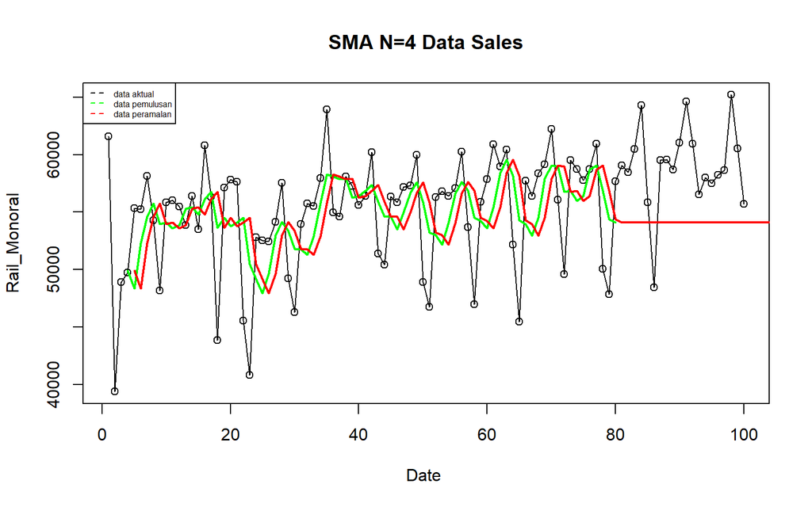

```r
ts.plot(data.ts, xlab="Date ", ylab="Rail_Monoral", main= "SMA N=4 Data Sales")
points(data.ts)
lines(data.gab[,2],col="green",lwd=2)
lines(data.gab[,3],col="red",lwd=2)
legend("topleft",c("data aktual","data pemulusan","data peramalan"), lty=8, col=c("black","green","red"), cex=0.5)
```

Selanjutnya perhitungan akurasi dilakukan dengan ukuran akurasi *Sum Squares Error* (SSE), *Mean Square Error* (MSE) dan *Mean Absolute Percentage Error* (MAPE). Perhitungan akurasi dilakukan baik pada data latih maupun pada data uji.

$$SSE = \sum_{t=1}^{n} (y_t - \hat{y}_t)^2$$
$$MSE = \frac{1}{n} \sum_{t=1}^{n} (y_t - \hat{y}_t)^2$$
$$MAPE = \frac{1}{n} \sum_{t=1}^{n} \left|\frac{y_t -
\hat{y}_t}{y_t}\right| * 100$$

## Evaluasi

### Data Latih

```r
#Menghitung nilai keakuratan data latih
error_train.sma = train_ma.ts-data.ramal[1:length(train_ma.ts)]

SSE_train.sma = sum(error_train.sma[5:length(train_ma.ts)]^2)
MSE_train.sma = mean(error_train.sma[5:length(train_ma.ts)]^2)
MAPE_train.sma = mean(abs((error_train.sma[5:length(train_ma.ts)]/train_ma.ts[5:length(train_ma.ts)])*100))

akurasi_train.sma <- matrix(c(SSE_train.sma, MSE_train.sma, MAPE_train.sma))
row.names(akurasi_train.sma)<- c("SSE", "MSE", "MAPE")
colnames(akurasi_train.sma) <- c("Akurasi m = 4")
akurasi_train.sma
```

```
##      Akurasi m = 4
## SSE   2.125628e+09
## MSE   2.796879e+07
## MAPE  8.288040e+00
```

### Data Uji

```r
#Menghitung nilai keakuratan data uji
error_test.sma = test_ma.ts-data.gab[81:100,3]

SSE_test.sma = sum(error_test.sma^2)
MSE_test.sma = mean(error_test.sma^2)
MAPE_test.sma = mean(abs((error_test.sma/test_ma.ts*100)))

akurasi_test.sma <- matrix(c(SSE_test.sma, MSE_test.sma, MAPE_test.sma))
row.names(akurasi_test.sma)<- c("SSE", "MSE", "MAPE")
colnames(akurasi_test.sma) <- c("Akurasi m = 4")
akurasi_test.sma
```

```
##      Akurasi m = 4
## SSE   7.444550e+08
## MSE   3.722275e+07
## MAPE  9.198098e+00
```

Perhitungan akurasi menggunakan data latih menghasilkan nilai MAPE yang kurang dari 10% sehingga nilai akurasi ini dapat dikategorikan sebagai sangat baik.

# Double Moving Average (DMA)

Metode pemulusan Double Moving Average (DMA) pada dasarnya mirip dengan SMA. Namun demikian, metode ini lebih cocok digunakan untuk pola data trend. Proses pemulusan dengan rata rata dalam metode ini dilakukan sebanyak 2 kali.

- **Tahap I:**

$$S_{1,t} = \frac{1}{m} \sum_{i=t-m+1}^{t} X_i$$

- **Tahap II:**

$$S_{2,t} = \frac{1}{m} \sum_{i=t-m+1}^{t} S_{1,i}$$

Forecast $h$ langkah ke depan dihitung dengan:

$$F_{2,t,t+h} = A_t + B_t \,(h)$$

dengan komponen level ($A_t$) dan tren ($B_t$):

$$A_t = 2S_{1,t} - S_{2,t}
\qquad\text{dan}\qquad
B_t = \frac{2}{m-1}\,\big(S_{1,t} - S_{2,t}\big)$$

## Pemulusan

```r
dma <- SMA(data.sma, n = 4)
At <- 2*data.sma - dma
Bt <- 2/(4-1)*(data.sma - dma)
data.dma<- At+Bt
data.ramal2<- c(NA, data.dma)

t = 1:24
f = c()

for (i in t) {
  f[i] = At[length(At)] + Bt[length(Bt)]*(i)
}

data.gab2 <- cbind(aktual = c(data.ts),
                   pemulusan1 = c(data.sma,rep(NA,24)),
                   pemulusan2 = c(dma, rep(NA,24)),
                   At = c(At, rep(NA,24)),
                   Bt = c(Bt,rep(NA,24)),
                   ramalan = c(data.ramal2, f[-1]))
data.gab2
```

```
##        aktual pemulusan1 pemulusan2       At           Bt  ramalan
##   [1,]  61590         NA         NA       NA           NA       NA
##   [2,]  39374         NA         NA       NA           NA       NA
##   [3,]  48918         NA         NA       NA           NA       NA
##   [4,]  49734   49904.00         NA       NA           NA       NA
##   [5,]  55323   48337.25         NA       NA           NA       NA
##   [6,]  55233   52302.00         NA       NA           NA       NA
##   [7,]  58146   54609.00   51288.06 57929.94  2213.958333       NA
##   [8,]  54283   55746.25   52748.62 58743.88  1998.416667 60143.90
##   [9,]  48146   53952.00   54152.31 53751.69  -133.541667 60742.29
##  [10,]  55820   54098.75   54601.50 53596.00  -335.166667 53618.15
##  [11,]  56036   53571.25   54342.06 52800.44  -513.875000 53260.83
##  [12,]  55484   53871.50   53873.38 53869.62    -1.250000 52286.56
##  [13,]  53859   55299.75   54210.31 56389.19   726.291667 53868.38
##  [14,]  56406   55446.25   54547.19 56345.31   599.375000 57115.48
```

[output cut: 90 more lines]

Hasil pemulusan menggunakan metode DMA divisualisasikan sebagai berikut

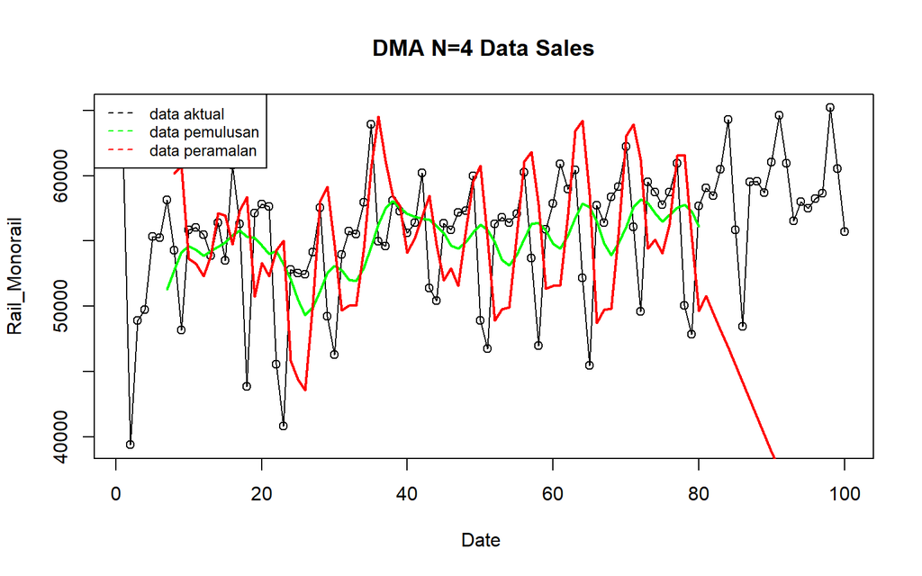

```r
ts.plot(data.ts, xlab="Date ", ylab="Rail_Monorail", main= "DMA N=4 Data Sales")
points(data.ts)
lines(data.gab2[,3],col="green",lwd=2)
lines(data.gab2[,6],col="red",lwd=2)
legend("topleft",c("data aktual","data pemulusan","data peramalan"), lty=8, col=c("black","green","red"), cex=0.8)
```

## Evaluasi

### Data Latih

Selanjutnya perhitungan akurasi dilakukan baik pada data latih maupun data uji. Perhitungan akurasi dilakukan dengan ukuran akurasi SSE, MSE dan MAPE.

```r
#Menghitung nilai keakuratan data latih
error_train.dma = train_ma.ts-data.ramal2[1:length(train_ma.ts)]

SSE_train.dma = sum(error_train.dma[8:length(train_ma.ts)]^2)
MSE_train.dma = mean(error_train.dma[8:length(train_ma.ts)]^2)
MAPE_train.dma = mean(abs((error_train.dma[8:length(train_ma.ts)]/train_ma.ts[8:length(train_ma.ts)])*100))

akurasi_train.dma <- matrix(c(SSE_train.dma, MSE_train.dma, MAPE_train.dma))
row.names(akurasi_train.dma)<- c("SSE", "MSE", "MAPE")
colnames(akurasi_train.dma) <- c("Akurasi m = 4")
akurasi_train.dma
```

```
##      Akurasi m = 4
## SSE   3.351268e+09
## MSE   4.590779e+07
## MAPE  1.081429e+01
```

### Data Uji

```r
#Menghitung nilai keakuratan data uji
error_test.dma = test_ma.ts-data.gab2[81:100,6]
SSE_test.dma = sum(error_test.dma^2)
MSE_test.dma = mean(error_test.dma^2)
MAPE_test.dma = mean(abs((error_test.dma/test_ma.ts*100)))

akurasi_test.dma <- matrix(c(SSE_test.dma, MSE_test.dma, MAPE_test.dma))
row.names(akurasi_test.dma)<- c("SSE", "MSE", "MAPE")
colnames(akurasi_test.dma) <- c("Akurasi m = 4")
akurasi_test.dma
```

```
##      Akurasi m = 4
## SSE   1.022540e+10
## MSE   5.112701e+08
## MAPE  3.502539e+01
```

# Single Exponential Smoothing

Single Exponential Smoothing (SES) adalah metode peramalan deret waktu yang dikembangkan untuk mengatasi kelemahan Moving Average. Jika pada Moving Average setiap data periode sebelumnya dianggap memiliki bobot yang sama, maka SES memberikan bobot yang semakin mengecil secara eksponensial terhadap data lama, sehingga data terbaru diberi bobot lebih besar.

Single Exponential Smoothing merupakan metode pemulusan yang tepat digunakan untuk data dengan pola stasioner atau konstan.

Nilai pemulusan pada periode ke-t didapat dari persamaan:

$$\tilde{y}_T=\lambda
y_t+(1-\lambda)\tilde{y}_{T-1}$$

Nilai parameter $\lambda$ adalah nilai antara 0 dan 1.

Nilai pemulusan periode ke-t bertindak sebagai nilai ramalan pada periode ke-$(T+\tau)$.

$$\tilde{y}_{T+\tau}(T)=\tilde{y}_T$$

Pemulusan dengan metode SES dapat dilakukan dengan dua fungsi dari *packages* berbeda, yaitu (1) fungsi `ses()` dari *packages* `forecast` dan (2) fungsi `HoltWinters` dari *packages* `stats` .

## Fungsi SES

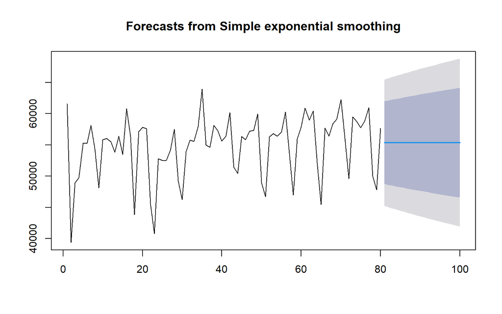

```r
#Cara 1 (fungsi ses)
ses.1 <- ses(train_ma.ts, h = 20, alpha = 0.2)
plot(ses.1)
```

```r
ses.1
```

```
##     Point Forecast    Lo 80    Hi 80    Lo 95    Hi 95
##  81        55363.5 48747.57 61979.43 45245.30 65481.69
##  82        55363.5 48616.54 62110.45 45044.92 65682.07
##  83        55363.5 48488.02 62238.98 44848.36 65878.63
##  84        55363.5 48361.85 62365.14 44655.41 66071.59
##  85        55363.5 48237.92 62489.07 44465.87 66261.13
##  86        55363.5 48116.11 62610.89 44279.57 66447.42
##  87        55363.5 47996.31 62730.69 44096.35 66630.64
##  88        55363.5 47878.43 62848.57 43916.07 66810.93
##  89        55363.5 47762.37 62964.63 43738.58 66988.42
##  90        55363.5 47648.06 63078.93 43563.76 67163.24
##  91        55363.5 47535.42 63191.57 43391.49 67335.51
##  92        55363.5 47424.38 63302.62 43221.66 67505.33
##  93        55363.5 47314.87 63412.13 43054.18 67672.81
##  94        55363.5 47206.83 63520.17 42888.95 67838.05
##  95        55363.5 47100.20 63626.79 42725.88 68001.12
##  96        55363.5 46994.93 63732.06 42564.88 68162.11
##  97        55363.5 46890.97 63836.02 42405.89 68321.11
##  98        55363.5 46788.27 63938.73 42248.82 68478.18
##  99        55363.5 46686.78 64040.21 42093.61 68633.39
## 100        55363.5 46586.47 64140.52 41940.20 68786.80
```

Pada fungsi `ses()` , terdapat beberapa argumen yang umum digunakan, yaitu

- `y` : nilai data deret waktu
- `alpha` : parameter pemulusan utama (0–1), mengatur bobot data terbaru vs data lama.
- `beta` : parameter pemulusan tren.
- `gamma` : parameter pemulusan musiman.
- `h` : jumlah periode ke depan yang ingin diramalkan (forecast horizon).

### Pemulusan

Untuk mendapatkan gambar hasil pemulusan pada data latih dengan fungsi `ses()` , perlu digunakan fungsi `autoplot()` dan `autolayer()` dari *library packages* `ggplot2` .

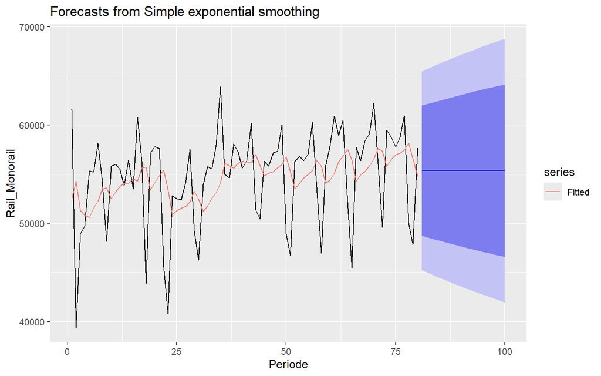

```r
autoplot(ses.1) +
  autolayer(fitted(ses.1), series="Fitted") +
  ylab("Rail_Monorail") + xlab("Periode")
```

### Evaluasi

```r
accuracy(ses.1, testing_ma$rail_monorail)
```

```
##                     ME    RMSE      MAE        MPE     MAPE      MASE
## Training set  181.7091 5097.50 4043.054 -0.5405874 7.787013 0.9067718
## Test set     3703.0020 5140.53 4396.152  5.9038656 7.335047 0.9859641
##                    ACF1
## Training set 0.09411838
## Test set             NA
```

## Holt-Winter

Selanjutnya akan digunakan fungsi `HoltWinters()` dengan nilai inisialisasi parameter dan panjang periode peramalan yang sama dengan fungsi `ses()` .

## Pemulusan

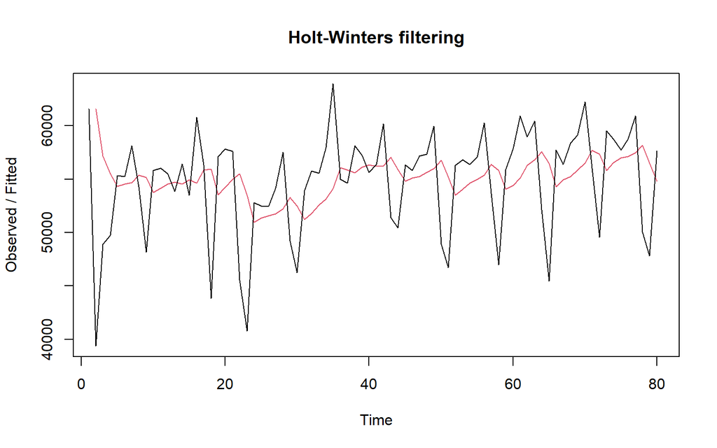

```r
#Cara 2 (fungsi Holtwinter)
ses1<- HoltWinters(train_ma.ts, gamma = FALSE, beta = FALSE, alpha = 0.2)
plot(ses1)
```

```r
#ramalan
ramalan1<- forecast(ses1, h=20)
ramalan1
```

```
##     Point Forecast    Lo 80    Hi 80    Lo 95    Hi 95
##  81        55363.5 48407.19 62319.80 44724.75 66002.25
##  82        55363.5 48269.43 62457.57 44514.06 66212.94
##  83        55363.5 48134.29 62592.70 44307.38 66419.61
##  84        55363.5 48001.64 62725.36 44104.50 66622.49
##  85        55363.5 47871.33 62855.67 43905.21 66821.78
##  86        55363.5 47743.25 62983.75 43709.33 67017.67
##  87        55363.5 47617.28 63109.71 43516.69 67210.31
##  88        55363.5 47493.34 63233.66 43327.13 67399.87
##  89        55363.5 47371.31 63355.68 43140.50 67586.49
##  90        55363.5 47251.12 63475.87 42956.69 67770.31
##  91        55363.5 47132.69 63594.31 42775.56 67951.44
##  92        55363.5 47015.93 63711.06 42597.00 68130.00
##  93        55363.5 46900.79 63826.21 42420.90 68306.10
##  94        55363.5 46787.19 63939.81 42247.17 68479.83
##  95        55363.5 46675.08 64051.92 42075.70 68651.29
##  96        55363.5 46564.39 64162.61 41906.43 68820.57
##  97        55363.5 46455.08 64271.92 41739.25 68987.75
##  98        55363.5 46347.10 64379.90 41574.10 69152.89
##  99        55363.5 46240.39 64486.61 41410.91 69316.09
## 100        55363.5 46134.92 64592.08 41249.60 69477.40
```

### Evaluasi

```r
accuracy(ramalan1, testing_ma$rail_monorail)
```

```
##                     ME     RMSE      MAE       MPE     MAPE      MASE      ACF1
## Training set -394.0824 5407.947 4070.088 -1.673108 7.973175 0.9128350 0.2091649
## Test set     3703.0018 5140.530 4396.152  5.903865 7.335047 0.9859641        NA
```

Fungsi `HoltWinters` memiliki argumen yang sama dengan fungsi `ses()` . Argumen-argumen fungsi dapat dilihat lebih lanjut dengan `?ses()` atau `?HoltWinters` .

## SES Optimum

Nilai parameter $\alpha$ dari fungsi dapat dioptimalkan menyesuaikan dari *error*-nya paling minimumnya. Caranya adalah dengan membuat parameter $\alpha =$ `NULL` .

### Pemulusan

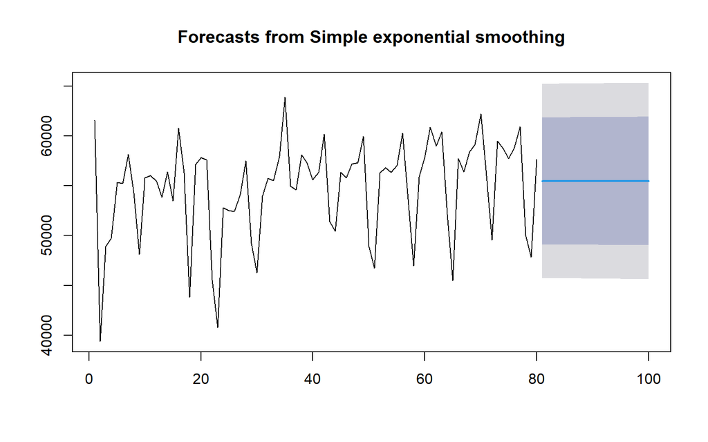

```r
#SES
ses.opt <- ses(train_ma.ts, h = 20, alpha = NULL)
plot(ses.opt)
```

```r
ses.opt
```

```
##     Point Forecast    Lo 80    Hi 80    Lo 95    Hi 95
##  81       55492.25 49115.31 61869.18 45739.57 65244.92
##  82       55492.25 49111.35 61873.14 45733.51 65250.99
##  83       55492.25 49107.39 61877.11 45727.45 65257.05
##  84       55492.25 49103.43 61881.07 45721.39 65263.10
##  85       55492.25 49099.47 61885.02 45715.34 65269.15
##  86       55492.25 49095.52 61888.98 45709.29 65275.20
##  87       55492.25 49091.56 61892.93 45703.25 65281.25
##  88       55492.25 49087.61 61896.88 45697.21 65287.29
##  89       55492.25 49083.67 61900.83 45691.17 65293.32
##  90       55492.25 49079.72 61904.77 45685.14 65299.36
##  91       55492.25 49075.78 61908.71 45679.11 65305.39
##  92       55492.25 49071.84 61912.65 45673.08 65311.41
##  93       55492.25 49067.90 61916.59 45667.06 65317.44
##  94       55492.25 49063.97 61920.53 45661.04 65323.45
##  95       55492.25 49060.03 61924.46 45655.02 65329.47
##  96       55492.25 49056.10 61928.39 45649.01 65335.48
##  97       55492.25 49052.17 61932.32 45643.01 65341.49
##  98       55492.25 49048.25 61936.24 45637.00 65347.49
##  99       55492.25 49044.33 61940.17 45631.00 65353.49
## 100       55492.25 49040.40 61944.09 45625.01 65359.49
```

### Evaluasi

```r
accuracy(ses.opt,testing_ma$rail_monorail)
```

```
##                     ME     RMSE      MAE        MPE     MAPE      MASE
## Training set  529.3985 4913.354 3966.285 0.08577286 7.576384 0.8895541
## Test set     3574.2536 5048.575 4280.278 5.68504413 7.142809 0.9599761
##                   ACF1
## Training set 0.1698658
## Test set            NA
```

# *Double Exponential Smoothing* (DES)

Metode pemulusan *Double Exponential Smoothing* (DES) digunakan untuk data yang memiliki pola tren. Metode DES adalah metode semacam SES, hanya saja dilakukan dua kali, yaitu pertama untuk tahapan ‘level’ dan kedua untuk tahapan ‘tren’. Pemulusan menggunakan metode ini akan menghasilkan peramalan tidak konstan untuk periode berikutnya.

## Holt-Winters

Pemulusan dengan metode DES kali ini akan menggunakan fungsi `HoltWinters()` . Jika sebelumnya nilai argumen `beta` dibuat `FALSE` , kali ini argumen tersebut akan diinisialisasi bersamaan dengan nilai `alpha` .

### Pemulusan

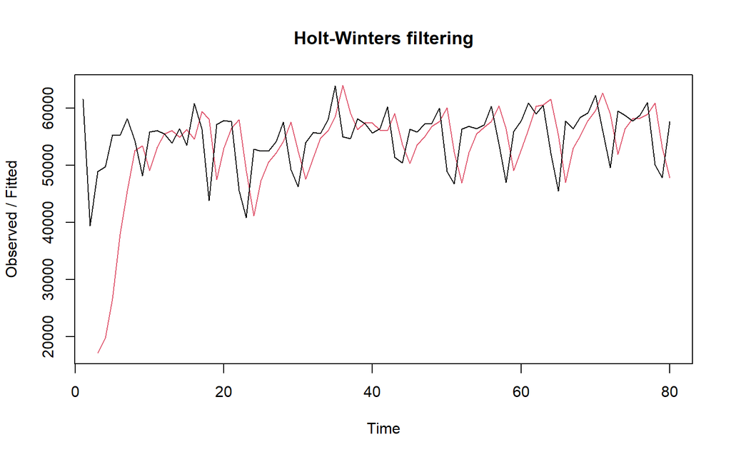

```r
des<- HoltWinters(train_ma.ts, gamma = FALSE, beta = 0.3, alpha = 0.6)
plot(des)
```

```r
#ramalan
ramalandes<- forecast(des, h=20)
ramalandes
```

```
##     Point Forecast      Lo 80     Hi 80       Lo 95     Hi 95
##  81       53325.26  42394.591  64255.94   36608.243  70042.28
##  82       52934.88  39072.301  66797.45   31733.897  74135.86
##  83       52544.49  35158.190  69930.79   25954.439  79134.54
##  84       52154.10  30763.471  73544.73   19439.955  84868.25
##  85       51763.71  25961.770  77565.66   12303.046  91224.38
##  86       51373.33  20802.598  81944.05    4619.432  98127.22
##  87       50982.94  15320.793  86645.08   -3557.606 105523.48
##  88       50592.55   9542.092  91643.01  -12188.709 113373.81
##  89       50202.16   3486.358  96917.97  -21243.496 121647.82
##  90       49811.78  -2830.505 102454.06  -30697.645 130321.20
##  91       49421.39  -9395.379 108238.16  -40531.096 139373.88
##  92       49031.00 -16197.184 114259.19  -50726.900 148788.90
##  93       48640.61 -23226.374 120507.60  -61270.460 158551.69
##  94       48250.23 -30474.597 126975.05  -72149.002 168649.46
##  95       47859.84 -37934.450 133654.13  -83351.203 179070.88
##  96       47469.45 -45599.302 140538.21  -94866.924 189805.83
##  97       47079.07 -53463.158 147621.29 -106686.997 200845.13
##  98       46688.68 -61520.562 154897.92 -118803.074 212180.43
##  99       46298.29 -69766.511 162363.09 -131207.505 223804.09
## 100       45907.90 -78196.392 170012.20 -143893.238 235709.04
```

Selanjutnya jika ingin membandingkan plot data latih dan data uji adalah sebagai berikut.

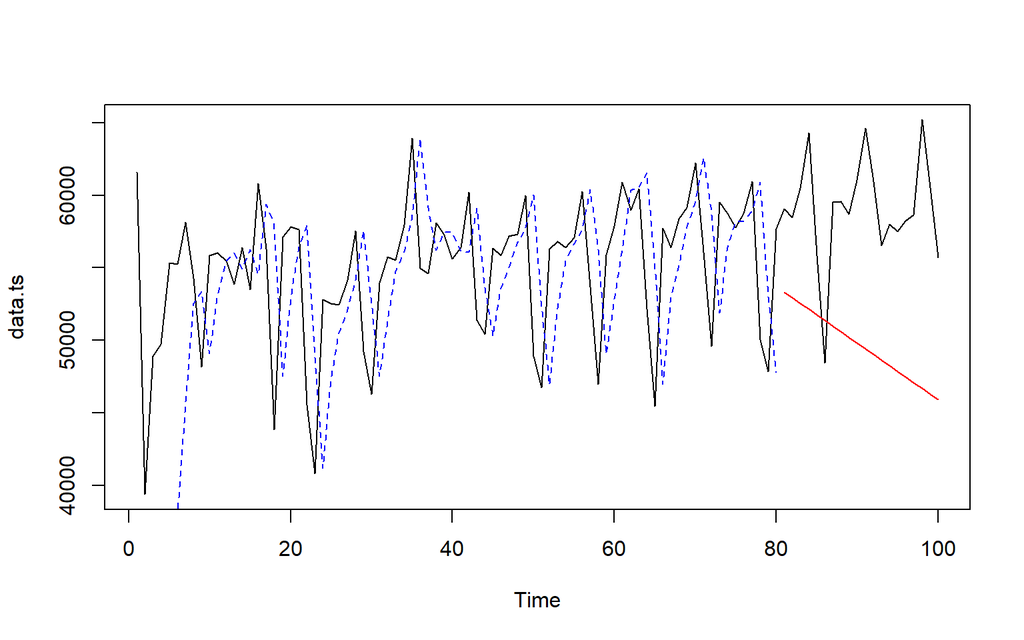

```r
plot(data.ts)
lines(des$fitted[,1], lty=2, col="blue")
lines(ramalandes$mean, col="red")
```

### Evaluasi

Setelah dilakukan peramalan, akan dilakukan perhitungan keakuratan hasil peramalan. Perhitungan akurasi ini dilakukan baik pada data latih dan data uji.

#### Akurasi Data Latih

```r
#Keakuratan Metode
#Pada data training
ssedes.train<-des$SSE
msedes.train<-ssedes.train/length(train_ma.ts)
sisaandes<-ramalandes$residuals
head(sisaandes)
```

```
## Time Series:
## Start = 1
## End = 6
## Frequency = 1
## [1]       NA       NA 31760.00 30019.20 28692.42 17318.08
```

```r
mapedes.train <- sum(abs(sisaandes[3:length(train_ma.ts)]/train_ma.ts[3:length(train_ma.ts)])
                      *100)/length(train_ma.ts)

akurasides <- matrix(c(ssedes.train,msedes.train,mapedes.train))
row.names(akurasides)<- c("SSE", "MSE", "MAPE")
colnames(akurasides) <- c("Akurasi lamda=0.6 dan gamma=0.3")
akurasides
```

```
##      Akurasi lamda=0.6 dan gamma=0.3
## SSE                     5.790095e+09
## MSE                     7.237619e+07
## MAPE                    1.121626e+01
```

#### Akurasi Data Uji

```r
selisihdes<-ramalandes$mean-testing_ma$rail_monorail
selisihdes
```

```
## Time Series:
## Start = 81
## End = 100
## Frequency = 1
##  [1]  -5749.736  -5522.124  -7919.511 -12157.899  -4099.286   2941.327
##  [7]  -8524.061  -8987.448  -8502.836 -11223.223 -15203.610 -11932.998
## [13]  -7868.385  -9747.773  -9623.160 -10747.547 -11584.935 -18513.322
## [19] -14227.710  -9804.097
```

```r
# SSE / MSE / RMSE / MAPE untuk masing-masing model
SSEtesting1  <- sum(selisihdes^2)
MSEtesting1  <- mean(selisihdes^2)
RMSEtesting1 <- sqrt(MSEtesting1)
MAPEtesting1 <- sum(abs(selisihdes/testing_ma$rail_monorail)*100)/length(testing_ma$rail_monorail)

# Tabel ringkas
akurasidestest <- matrix(c(SSEtesting1,MSEtesting1,MAPEtesting1))
row.names(akurasidestest)<- c("SSE", "MSE", "MAPE")
colnames(akurasidestest) <- c("Akurasi lamda=0.6 dan gamma=0.3")
akurasidestest
```

```
##      Akurasi lamda=0.6 dan gamma=0.3
## SSE                     2.165328e+09
## MSE                     1.082664e+08
## MAPE                    1.625769e+01
```

## DES Optimum

### Pemulusan

```r
#Lamda dan gamma optimum
des.opt<- HoltWinters(train_ma.ts, gamma = FALSE)
des.opt
```

```
## Holt-Winters exponential smoothing with trend and without seasonal component.
##
## Call:
## HoltWinters(x = train_ma.ts, gamma = FALSE)
##
## Smoothing parameters:
##  alpha: 1
##  beta : 0.2894097
##  gamma: FALSE
##
## Coefficients:
##        [,1]
## a 57658.000
## b  1126.196
```

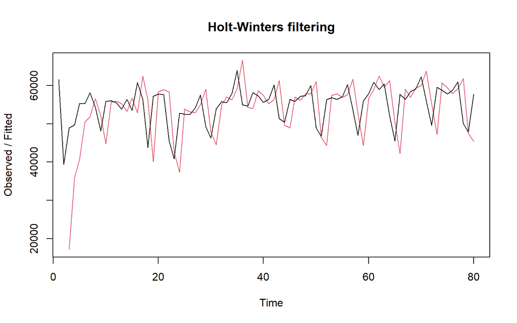

```r
plot(des.opt)
```

```r
#ramalan
ramalandesopt<- forecast(des.opt, h=20)
ramalandesopt
```

```
##     Point Forecast        Lo 80     Hi 80       Lo 95     Hi 95
##  81       58784.20   48961.6172  68606.77   43761.858  73806.53
##  82       59910.39   43882.4913  75938.29   35397.834  84422.95
##  83       61036.59   38734.2542  83338.92   26928.112  95145.06
##  84       62162.78   33281.1812  91044.38   17992.185 106333.38
##  85       63288.98   27465.5979  99112.36    8501.846 118076.11
##  86       64415.17   21275.1744 107555.17   -1561.762 130392.11
##  87       65541.37   14712.7924 116369.95  -12194.231 143276.97
##  88       66667.56    7786.9135 125548.22  -23382.620 156717.75
##  89       67793.76     507.9328 135079.59  -35111.033 170698.55
##  90       68919.96   -7113.3340 144953.25  -47362.926 185202.84
##  91       70046.15  -15066.2993 155158.60  -60122.109 200214.41
##  92       71172.35  -23340.8762 165685.57  -73373.155 215717.85
##  93       72298.54  -31927.5764 176524.66  -87101.551 231698.64
##  94       73424.74  -40817.5275 187667.00 -101293.730 248143.21
##  95       74550.93  -50002.4524 199104.32 -115937.032 265038.90
##  96       75677.13  -59474.6316 210828.89 -131019.652 282373.91
##  97       76803.33  -69226.8611 222833.51 -146530.572 300137.22
##  98       77929.52  -79252.4079 235111.45 -162459.495 318318.54
##  99       79055.72  -89544.9694 247656.40 -178796.781 336908.21
## 100       80181.91 -100098.6343 260462.46 -195533.391 355897.22
```

### Evaluasi

Selanjutnya akan dilakukan perhitungan akurasi pada data latih maupun data uji dengan ukuran akurasi SSE, MSE dan MAPE.

#### Akurasi Data Latih

```r
#Akurasi Data Training
ssedesopt.train<-des.opt$SSE
msedesopt.train<-ssedesopt.train/length(train_ma.ts)
sisaandesopt<-ramalandesopt$residuals
head(sisaandesopt)
```

```
## Time Series:
## Start = 1
## End = 6
## Frequency = 1
## [1]        NA        NA 31760.000 13840.348 14607.817  4701.173
```

```r
mapedesopt.train <- sum(abs(sisaandesopt[3:length(train_ma.ts)]/train_ma.ts[3:length(train_ma.ts)])*100)/length(train_ma.ts)

akurasidesopt <- matrix(c(ssedesopt.train,msedesopt.train,mapedesopt.train))
row.names(akurasidesopt)<- c("SSE", "MSE", "MAPE")
akurasidesopt
```

```
##              [,1]
## SSE  4.606847e+09
## MSE  5.758559e+07
## MAPE 9.601156e+00
```

#### Akurasi Data Uji

```r
#Akurasi Data Testing
selisihdesopt<-ramalandesopt$mean-testing_ma$rail_monorail
selisihdesopt
```

```
## Time Series:
## Start = 81
## End = 100
## Frequency = 1
##  [1]  -290.8044  1453.3912   572.5868 -2149.2176  7425.9780 15983.1736
##  [7]  6034.3693  7087.5649  9088.7605  7884.9561  5421.1517 10208.3473
## [13] 15789.5429 15426.7385 17067.9341 17460.1297 18139.3253 12727.5209
## [19] 18529.7166 24469.9122
```

```r
SSEtestingdesopt<-sum(selisihdesopt^2)
MSEtestingdesopt<-SSEtestingdesopt/length(testing_ma$rail_monorail)
MAPEtestingdesopt<-sum(abs(selisihdesopt/testing_ma$rail_monorail)*100)/length(testing_ma$rail_monorail)

akurasidestestopt <- matrix(c(SSEtestingdesopt,MSEtestingdesopt,MAPEtestingdesopt))
row.names(akurasidestestopt)<- c("SSE", "MSE", "MAPE")
akurasidestestopt
```

```
##              [,1]
## SSE  3.199392e+09
## MSE  1.599696e+08
## MAPE 1.841671e+01
```

# Evaluasi Metrik

## Ringkasan MAPE

- **Single Moving Average (m=4):** Menghasilkan nilai MAPE sebesar 8,29% pada data latih dan 9,20% pada data uji
- **Double Moving Average (m=4):** Menghasilkan nilai MAPE sebesar 10,81% pada data latih dan 35,03% pada data uji
- **Single Exponential Smoothing:**  
  SES Manual (α=0,2):** Menghasilkan nilai MAPE sebesar 7,78% pada data latih dan 7,34% pada data uji  
  **SES Holt-Winter (α=0,2):** Menghasilkan nilai MAPE sebesar 7,97% pada data latih dan 7,34% pada data uji  
  **SES Optimum:** Menghasilkan nilai MAPE sebesar 7,58% pada data latih dan 7,14% pada data uji
- **Double Exponential Smoothing:**  
  DES Holt-Winter (α=0,6 ; β=0,3):** Menghasilkan nilai MAPE sebesar 11,22% pada data latih dan 16,26% pada data uji  
  **DES Optimum:** Menghasilkan nilai MAPE sebesar 9,60% pada data latih dan 18,42% pada data uji

## Kesimpulan

Berdasarkan hasil evaluasi, **SSingle Exponential Smoothing (SES) Optimum** (nilai α dicari otomatis oleh fungsi ses()) merupakan metode terbaik untuk memodelkan pergerakan pengguna *monorail*. Hal ini dikarenakan metode tersebut menghasilkan tingkat kesalahan peramalan (MAPE) paling kecil pada data uji dibandingkan metode lainnya, yakni sebesar 7,14% — sedikit lebih rendah dibandingkan SES manual/Holt-Winter dengan α=0,2 tetap (MAPE data uji 7,34%).